# Advanced Visualization

# Topics

- ggplot2
- Maps

# ggplot2

ggplot2 developed by Hadley Wickham, based on the “grammar of graphics”

Particularly well suited for multi-dimensional, multivariate analysis.

Requires 3 things:

1. Data
2. Mapping
3. Geometric layers

# Data

```r
set.seed(1234)
N <- 30
df <- data.frame(Cohort = c(rep("F", N), rep("M", N))
                 , weight = c(rnorm(N, 150, 10), rnorm(N, 172, 10))
                 , height = c(rnorm(N, 64, 10), rnorm(N, 70, 10))
)

library(ggplot2)
basePlot <- ggplot(df)
```

# Mapping

Mappings bind data to visual elements. These are added with the `ggplot2::aes` function. We add the mapping to the plot object with the addition operator.

```r
basePlot <- basePlot + aes(x = height, y = weight)
```

We can map other aesthetic elements, as well. We’ll also map the color of the graphic elements to the `Cohort` data element.

```r
basePlot <- basePlot + aes(color = Cohort)
```

# Adding layers

We’re almost there. Although we have data and we’ve mapped to elements of a coordinate system, we haven’t specified what the visual elements should be. The `geom_*` family of functions add geometric shapes.

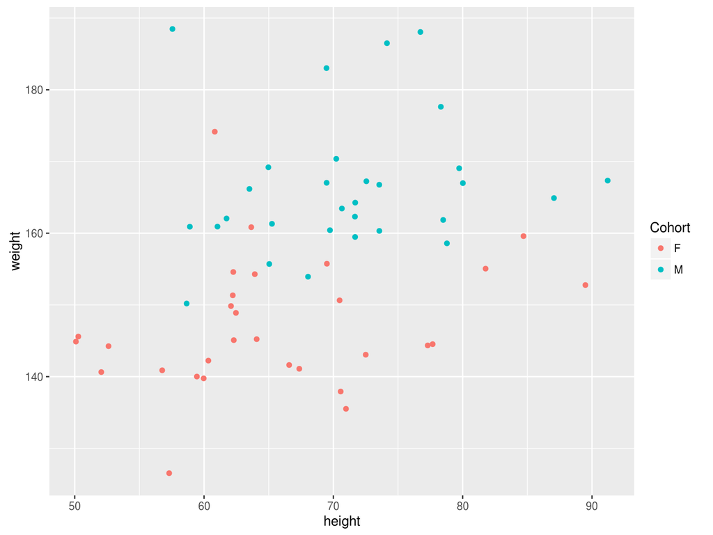

```r
basePlot <- basePlot + geom_point()
basePlot
```

# Typical geoms

- geom_line
- geom_point
- geom_bar
- geom_histogram
- geom_density
- geom_boxplot

Lots of others for things like area plots, step functions, dotplots, violin plots, errorbars, etc.

# One step

Typically we don’t do this in steps.

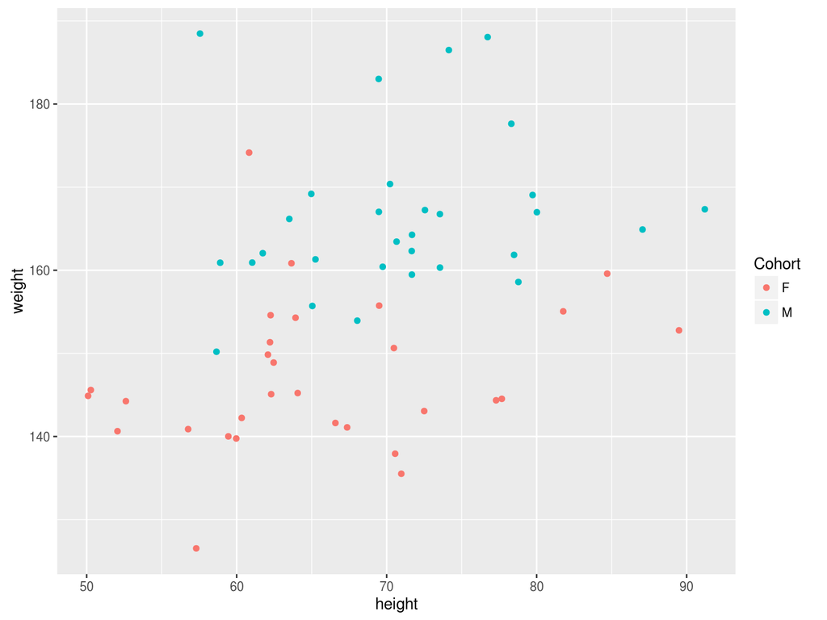

```r
plt <- ggplot(df, aes(x = height, y = weight, color = Cohort)) + geom_point()
plt
```

# Nothing wrong with adding two layers

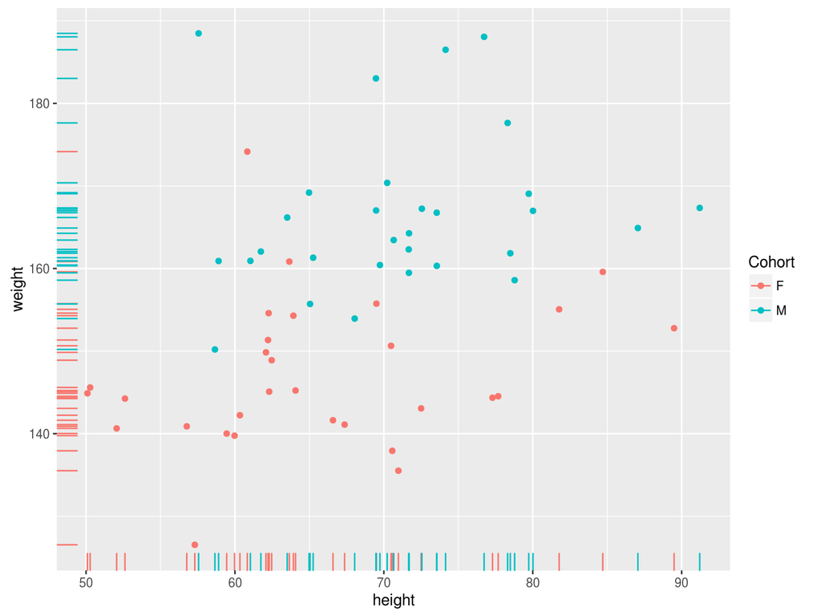

```r
ggplot(df, aes(x = height, y = weight, color = Cohort)) + geom_point() + geom_rug()
```

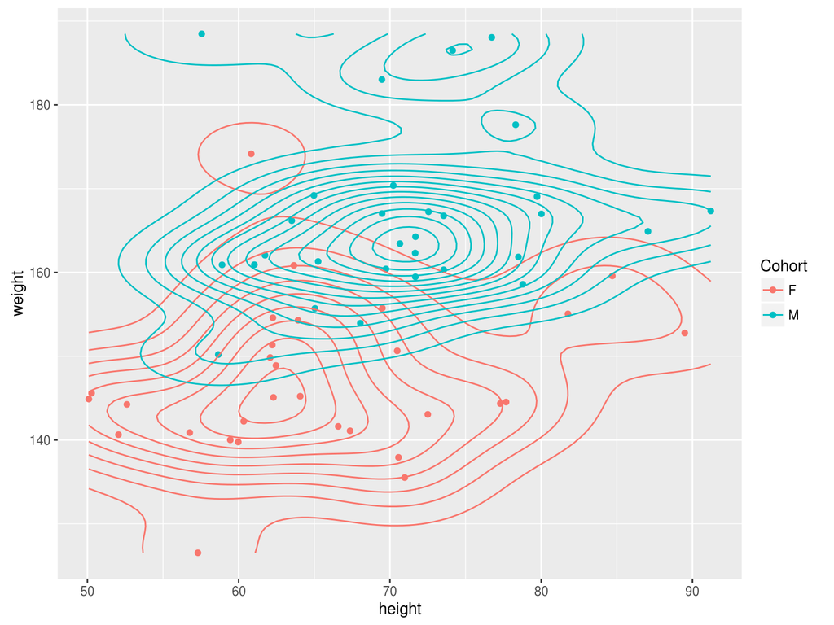

```r
ggplot(df, aes(x = height, y = weight, color = Cohort)) + geom_point() + geom_density2d()
```

# Facets

Facets split the data into groups and draws a different plot for each group.

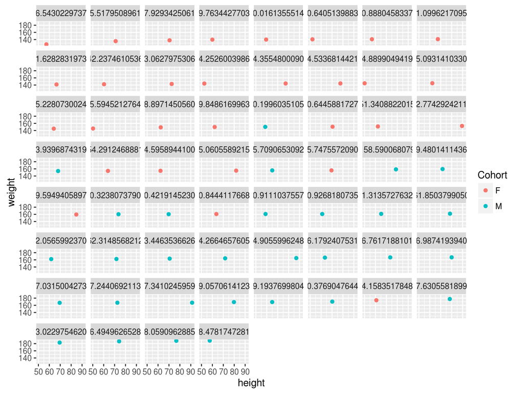

```r
plt <- ggplot(df, aes(x = height, y = weight, color = Cohort)) + geom_point() + facet_wrap(~ Cohort)

plt <- ggplot(df, aes(x = height, y = weight, color = Cohort)) + geom_point() + facet_wrap(~ weight)
plt
```

# Statistical transformations

We can also add all manner of statistical smoothers.

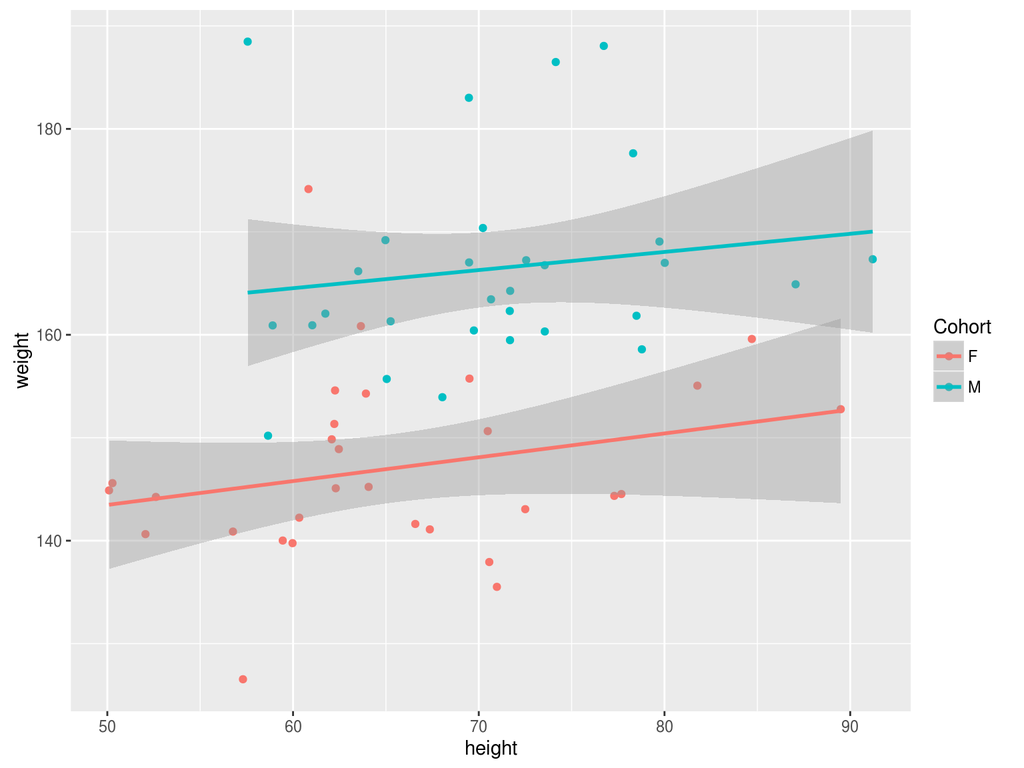

```r
plt <- ggplot(df, aes(x = height, y = weight, color = Cohort)) + geom_point() + geom_smooth(method = "lm")
plt
```

See `? stat_smooth` for more on smoothers.

# Scales

Scales control how things render on the plot. We must scale our numbers to the plotting device (typically a section of a computer screen.) We can also map things like color and axes to data values and control formatting.

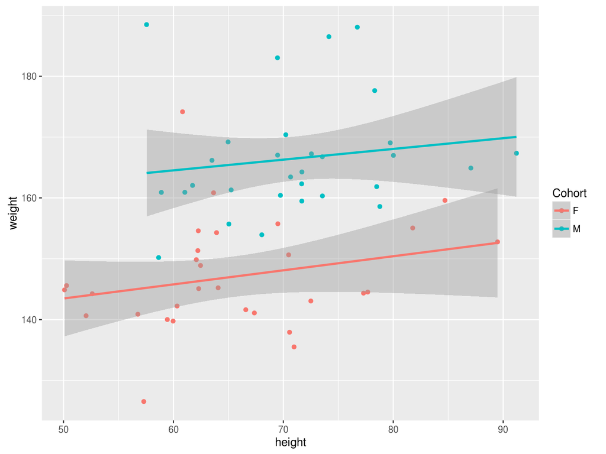

```r
plt + scale_x_continuous(labels = scales::comma)
```

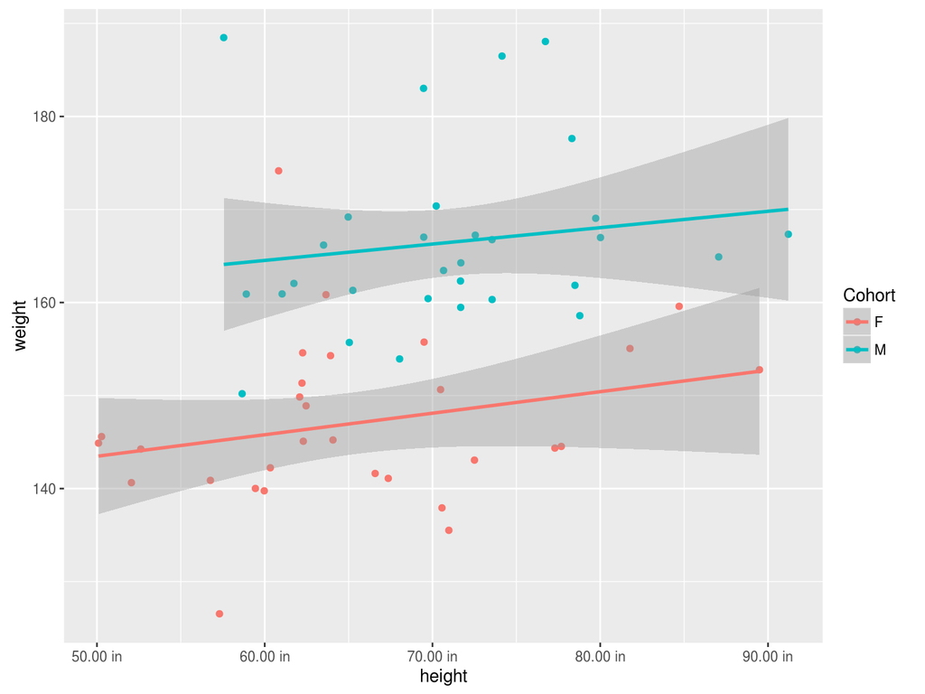

```r
plt + scale_x_continuous(labels = scales::unit_format(unit = "in", nsmall = 2))
```

*Very* detailed topic, particularly when we start talking about color. Your specific problem will likely require a bit of research and experimentation. StackOverflow.com is your friend.

# Other visual elements

Non-data elements are things like labels. Here’s a sample of a few:

- `xlab()`, `ylab()` -> `plt + ylab("This is my y label") + xlab("Here is an x label")`
- `ggtitle()` -> `plt + ggtitle("Title of my plot")`
- `labs()` -> `plt + labs(x = "x-axis title", title = "My title")`
- `theme_bw()`, `theme_minimal()` -> `plt + theme_bw()`
- The `theme()` function gives complete control over all non-data related visual elements
- Check out the `ggthemes` package

We won’t cover this here.

# Your turn

1. Create a scatter plot for policy year and number of claims
2. Color each point based on region
3. Add a linear smoother. Which region is showing the greatest increase in claims?
4. Form the policy frequency by taking the ratio of claims to policies. Plot this.

Extra credit:

1. Use the state data to create a time series number of claims. Facet by region.

# Answers

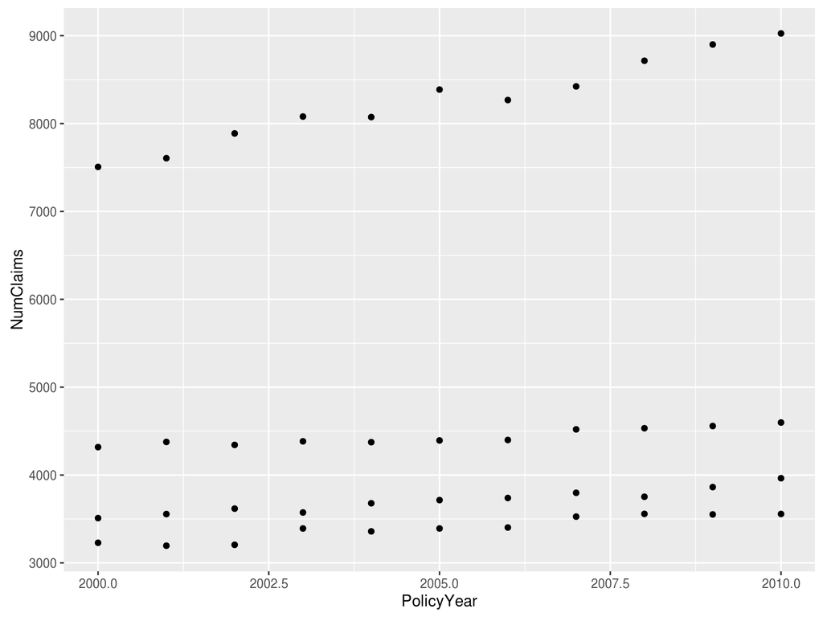

```r
library(raw)
data("RegionExperience")
plt1 <- ggplot(RegionExperience, aes(x = PolicyYear, y = NumClaims)) + geom_point()
plt1
```

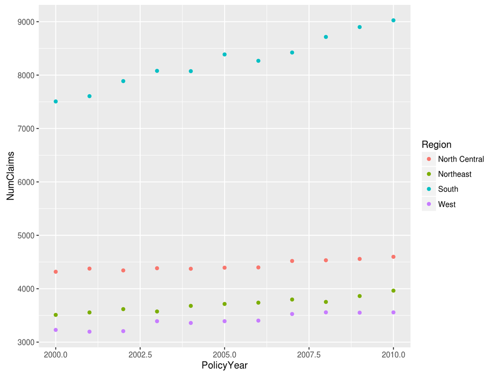

```r
plt2 <- plt1 + aes(color = Region)
plt2
```

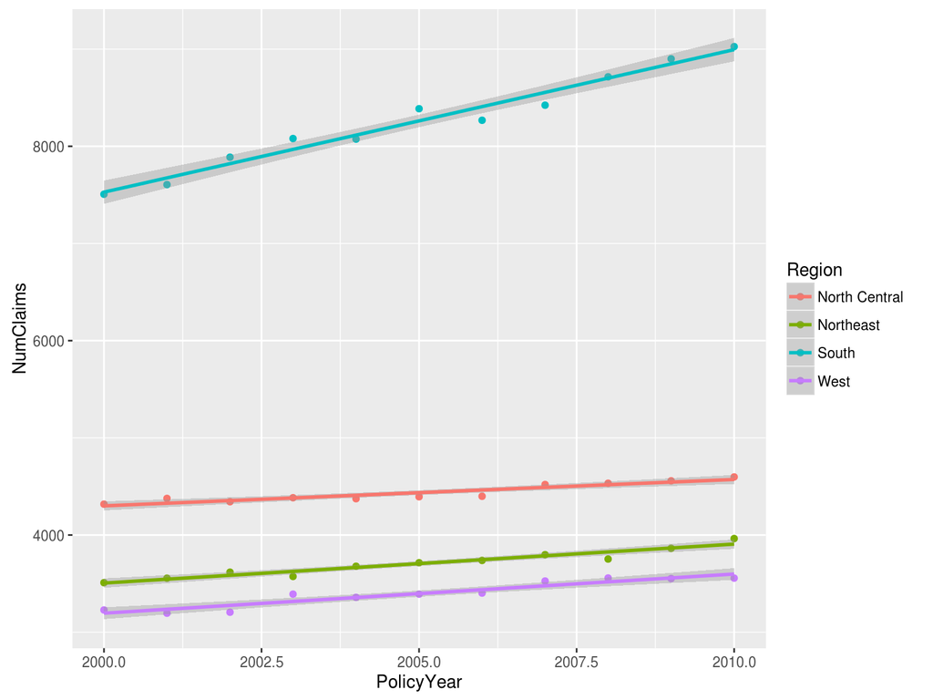

```r
plt3 <- plt2 + stat_smooth(method = "lm")
plt3
```

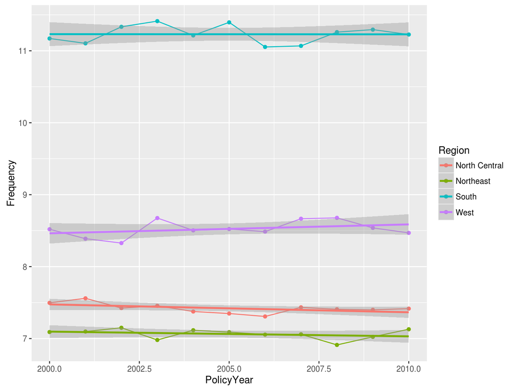

```r
RegionExperience$Frequency <- with(RegionExperience, NumClaims / NumPolicies)

plt4 <- ggplot(RegionExperience, aes(x = PolicyYear, y = Frequency, color = Region)) + geom_point() + geom_line() + stat_smooth(method = lm)
plt4
```

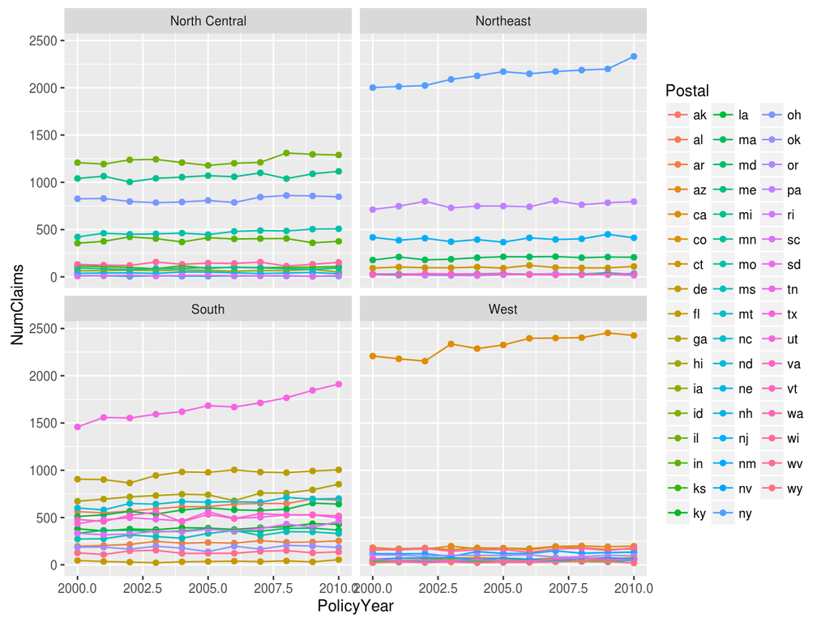

```r
data("StateExperience")
pltExtra <- ggplot(StateExperience, aes(x = PolicyYear, y = NumClaims, color = Postal)) + geom_point() + geom_line()
pltExtra + facet_wrap(~ Region)
```

# Maps!

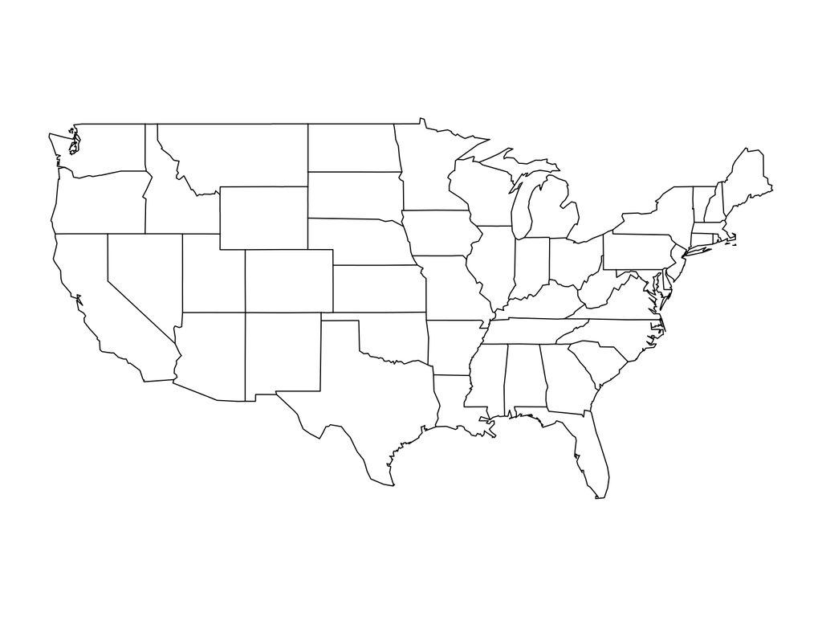

```r
library(maps)
map('state')
```

# Hurricanes

```r
library(raw)
data(Hurricane)

dfKatrina = subset(Hurricane, Name == 'KATRINA')
dfKatrina = dfKatrina[dfKatrina$Year == max(dfKatrina$Year), ]

dfHugo = subset(Hurricane, Name == 'HUGO')
dfHugo = dfHugo[dfHugo$Year == max(dfHugo$Year), ]

dfDonna = Hurricane[Hurricane$Name == 'DONNA', ]
dfDonna = dfDonna[dfDonna$Year == max(dfDonna$Year), ]
```

# Hurricanes

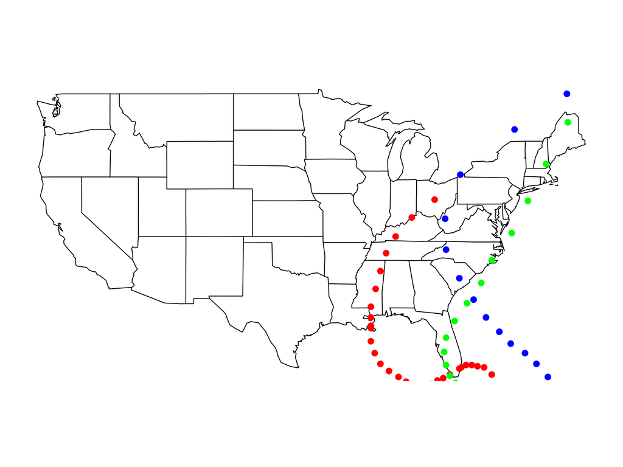

```r
map('state')
points(dfKatrina$Longitude, dfKatrina$Latitude, pch=19, col = 'red')
points(dfHugo$Longitude, dfHugo$Latitude, pch = 19, col = 'blue')
points(dfDonna$Longitude, dfDonna$Latitude, pch = 19, col = 'green')
```

# Choropleths the easy way

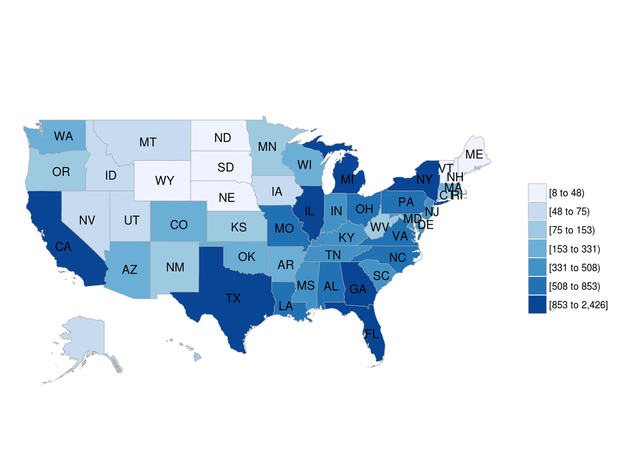

```r
library(choroplethr)
library(choroplethrMaps)

mapData <- subset(StateExperience, PolicyYear == 2010)
mapData$value <- mapData$NumClaims
mapData$region <- mapData$Fullname
state_choropleth(mapData)
```

# Choropleths the harder way

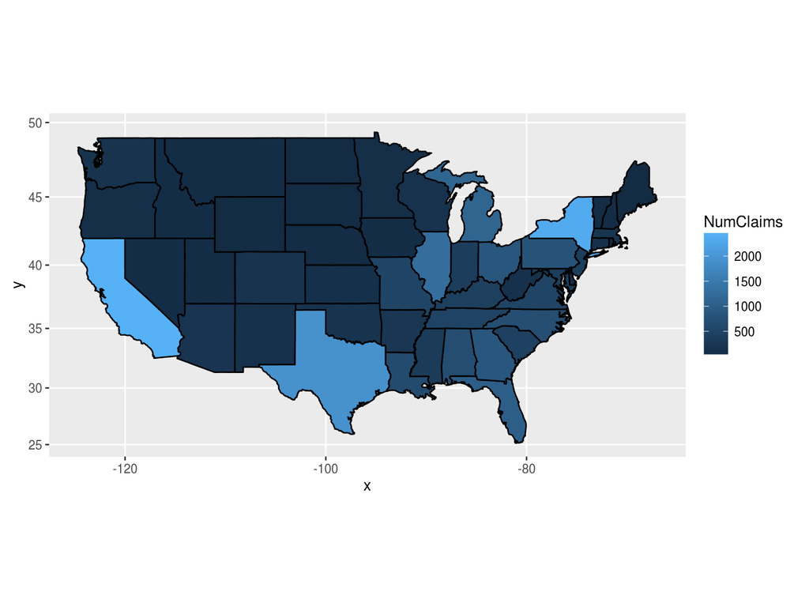

```r
states_map <- map_data("state")

plt <- ggplot(subset(StateExperience, PolicyYear == 2010), aes(map_id = Fullname))
plt <- plt + geom_map(aes(fill = NumClaims), color = "black", map = states_map)
plt <- plt + expand_limits(x = states_map$long, y = states_map$lat)
plt <- plt + coord_map()
plt
```

# Choropleths the really hard way

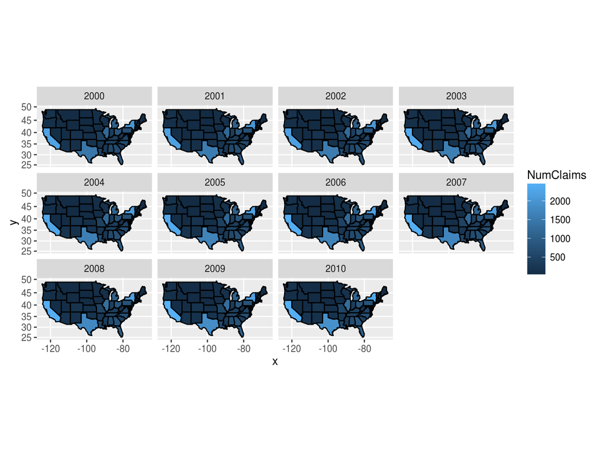

```r
plt <- ggplot(StateExperience, aes(map_id = Fullname))
plt <- plt + geom_map(aes(fill = NumClaims), color = "black", map = states_map)
plt <- plt + expand_limits(x = states_map$long, y = states_map$lat)
plt <- plt + facet_wrap( ~ PolicyYear)
plt <- plt + coord_map()
plt
```

# Summary

- `ggplot2` is difficult at first, but will repay your investment.
- Works very well with grouped data to color/facet points.
- Fine-tuning things like axis labels can be a headache, but will get easier. Yes, Excel makes it easier to add data labels and change colors. `ggplot2` makes it easier to work with data.
- Maps tend to be a killer viz. They use the same point and area logic as any other graphic.

# Reference

- http://www.rstudio.com/wp-content/uploads/2015/03/ggplot2-cheatsheet.pdf
- R Graphics Cookbook by Winston Chang
- http://vita.had.co.nz/papers/layered-grammar.html